# Biostat 203B Homework 2

Due Feb 7 @ 11:59PM

YU CHEN (305266880)

Use tidyverse (ggpot2, dplyr) to explore the [MIMIC-III](https://mimic.physionet.org) data introduced in [homework 1](https://ucla-biostat203b-2020winter.github.io/hw/hw1/hw1.html).

```r
library(tidyverse)
library(lubridate)
```

## Q1

Demographic information of the patients admitted into hospital is available in `ADMISSION.csv`. See https://mimic.physionet.org/mimictables/admissions/ for details of each field in this file. Summarize following variables using appropriate graphs:

- admission year
- admission month
- admission week day
- admission hour
- length of hospital stay
- admission type
- number of admissions per patient
- admission location
- insurance
- language
- religion
- martial status
- ethnicity
- death

Note it is possible that one patient (uniquely identified by the `SUBJECT_ID`) is admitted into hospital multiple times. When summarizing some demographic information, it makes sense to summarize based on only unique patients.

**SOLUTION**

Import data first.

```r
admission <- read_csv("/home/203bdata/mimic-iii/ADMISSIONS.csv",
                      col_types = cols(ROW_ID = col_integer(),
                                       SUBJECT_ID = col_integer(),
                                       HADM_ID = col_integer(),
                                       ADMITTIME = col_datetime(),
                                       DISCHTIME = col_datetime(),
                                       HOSPITAL_EXPIRE_FLAG = col_logical(),
                                       HAS_CHARTEVENTS_DATA = col_logical()))
admission
```

```
## # A tibble: 58,976 x 19
##    ROW_ID SUBJECT_ID HADM_ID ADMITTIME           DISCHTIME
##     <int>      <int>   <int> <dttm>              <dttm>
##  1     21         22  165315 2196-04-09 12:26:00 2196-04-10 15:54:00
##  2     22         23  152223 2153-09-03 07:15:00 2153-09-08 19:10:00
##  3     23         23  124321 2157-10-18 19:34:00 2157-10-25 14:00:00
##  4     24         24  161859 2139-06-06 16:14:00 2139-06-09 12:48:00
##  5     25         25  129635 2160-11-02 02:06:00 2160-11-05 14:55:00
##  6     26         26  197661 2126-05-06 15:16:00 2126-05-13 15:00:00
##  7     27         27  134931 2191-11-30 22:16:00 2191-12-03 14:45:00
##  8     28         28  162569 2177-09-01 07:15:00 2177-09-06 16:00:00
##  9     29         30  104557 2172-10-14 14:17:00 2172-10-19 14:37:00
## 10     30         31  128652 2108-08-22 23:27:00 2108-08-30 15:00:00
## # … with 58,966 more rows, and 14 more variables: DEATHTIME <dttm>,
## #   ADMISSION_TYPE <chr>, ADMISSION_LOCATION <chr>, DISCHARGE_LOCATION <chr>,
## #   INSURANCE <chr>, LANGUAGE <chr>, RELIGION <chr>, MARITAL_STATUS <chr>,
## #   ETHNICITY <chr>, EDREGTIME <dttm>, EDOUTTIME <dttm>, DIAGNOSIS <chr>,
## #   HOSPITAL_EXPIRE_FLAG <lgl>, HAS_CHARTEVENTS_DATA <lgl>
```

- Admission Year

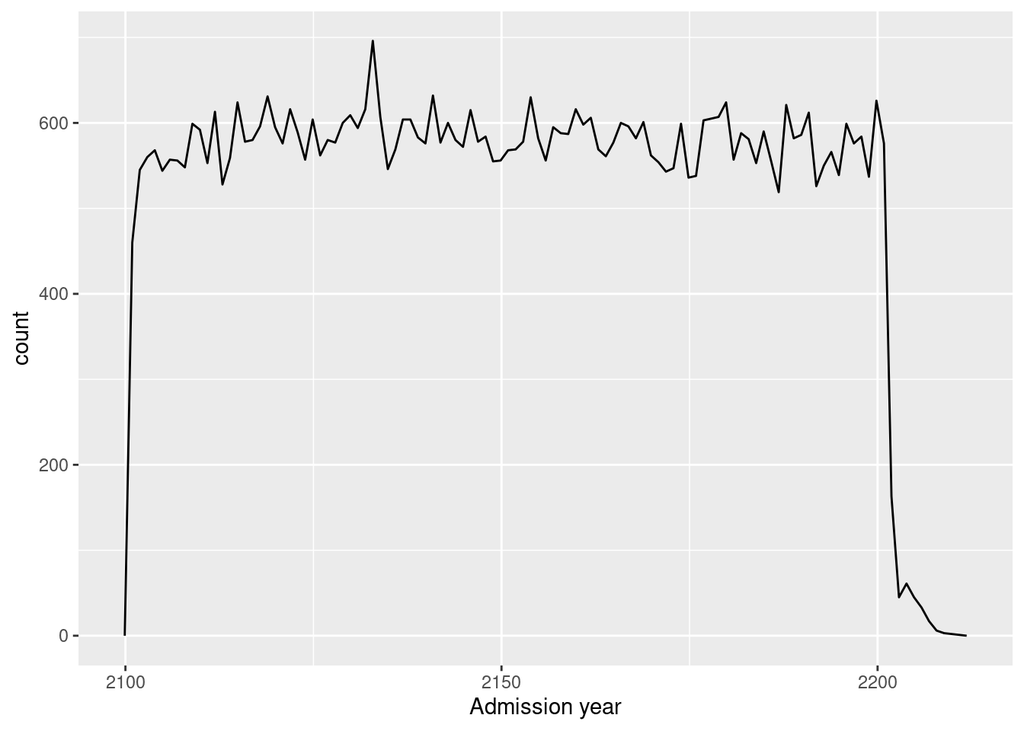

```r
admission %>%
  ggplot(aes(x = ADMITTIME)) +
  geom_freqpoly(binwidth = 31536000) +
  labs(x = "Admission year")
```

- Admission Month

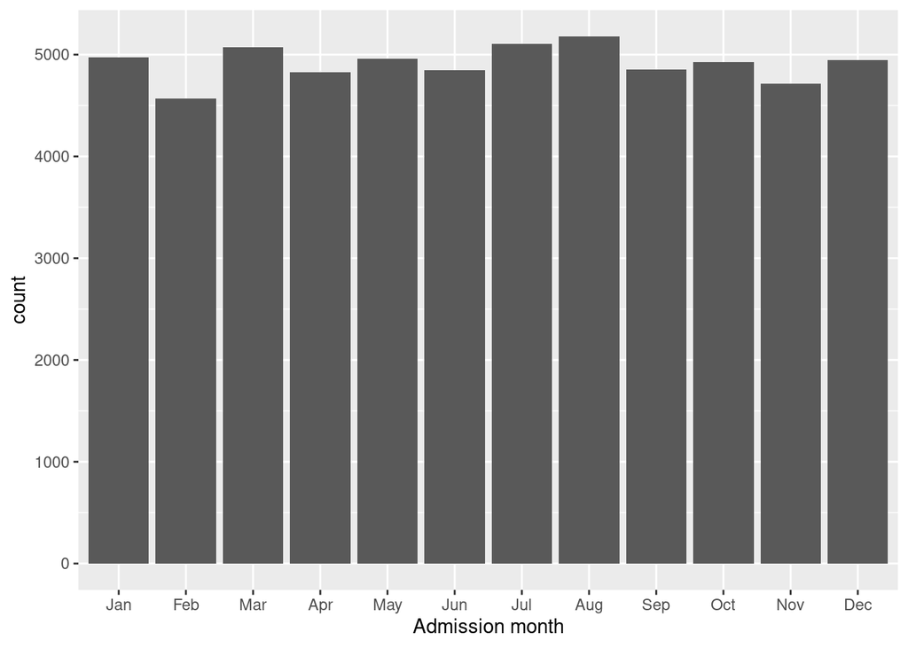

```r
admission %>%
  mutate(adm_month = month(ADMITTIME, label = TRUE)) %>%
  ggplot() +
  geom_bar(mapping = aes(x = adm_month)) +
  labs(x = 'Admission month')
```

- Admission week day

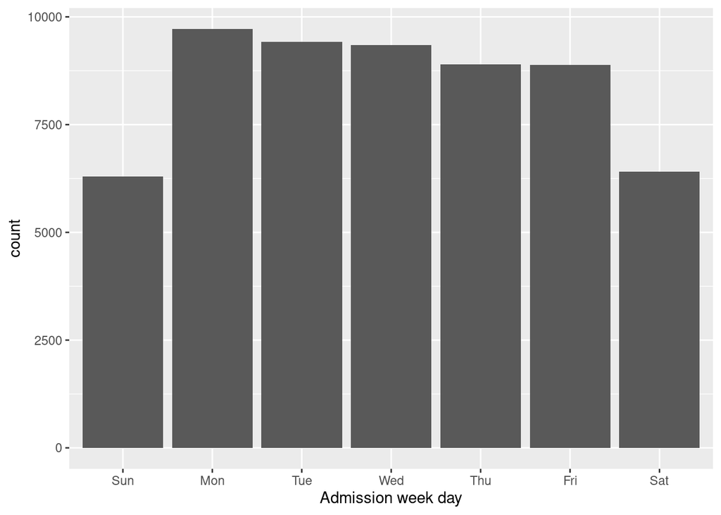

```r
admission %>%
  mutate(adm_wday = wday(ADMITTIME, label = TRUE)) %>%
  ggplot() +
  geom_bar(mapping = aes(x = adm_wday)) +
  labs(x = 'Admission week day')
```

We can see from the graph that weekdays are busier than weekends.

- Admission hour

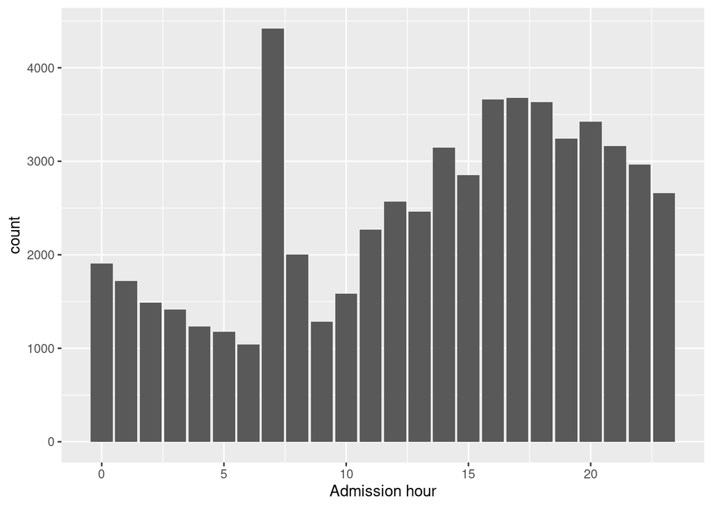

```r
admission %>%
  mutate(adm_hour = hour(ADMITTIME)) %>%
  ggplot() +
  geom_bar(mapping = aes(x = adm_hour)) +
  labs(x = 'Admission hour')
```

We can see that the 7 am is the busiest time of a day, probably because most people wait and go to hospital the minute it open. Also, hospitals are quite busy in the afternoon as well.

- Length of hospital stay

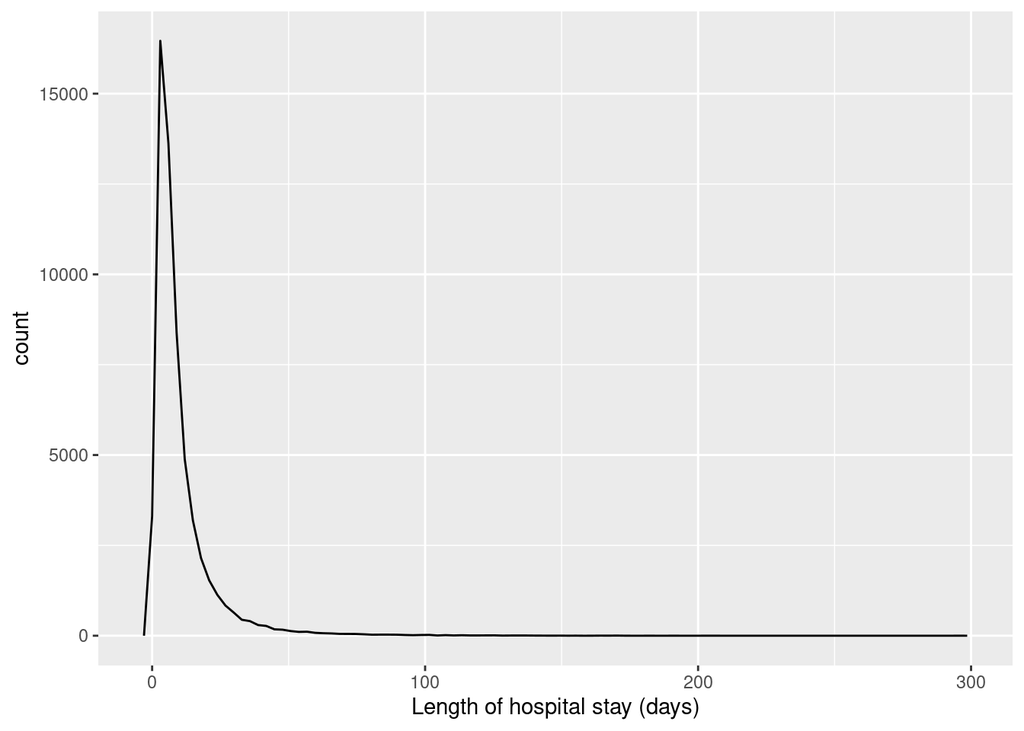

```r
admission %>%
  mutate(hospital_stay = as.numeric(as.duration(DISCHTIME - ADMITTIME) / 86400)) %>%
  ggplot(aes(x = hospital_stay)) +
  geom_freqpoly(bins = 100) +
  labs(x = "Length of hospital stay (days)")
```

A better picture of the pattern of length of hospital stay is shown below.

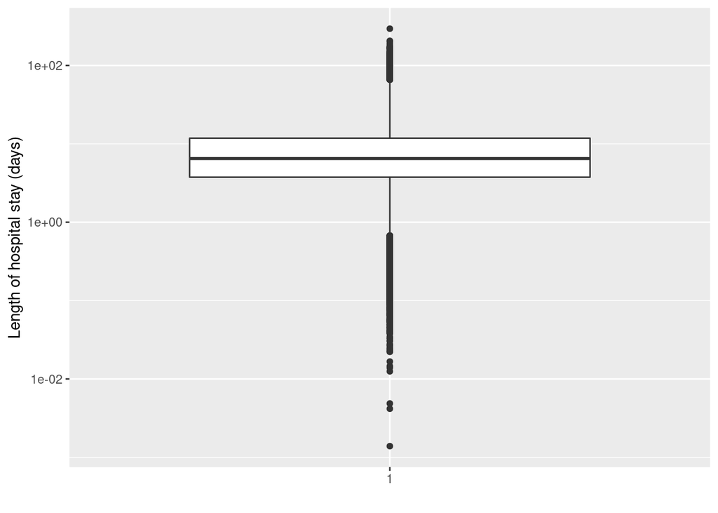

```r
admission %>%
  mutate(hospital_stay = as.numeric(as.duration(DISCHTIME - ADMITTIME) / 86400)) %>%
  ggplot() +
  geom_boxplot(mapping = aes(x = factor(1), y = hospital_stay)) +
  labs(x = "", y = "Length of hospital stay (days)") +
  scale_y_log10()
```

It is obvious that most patients stay in hospital for around a week.

- Admission type

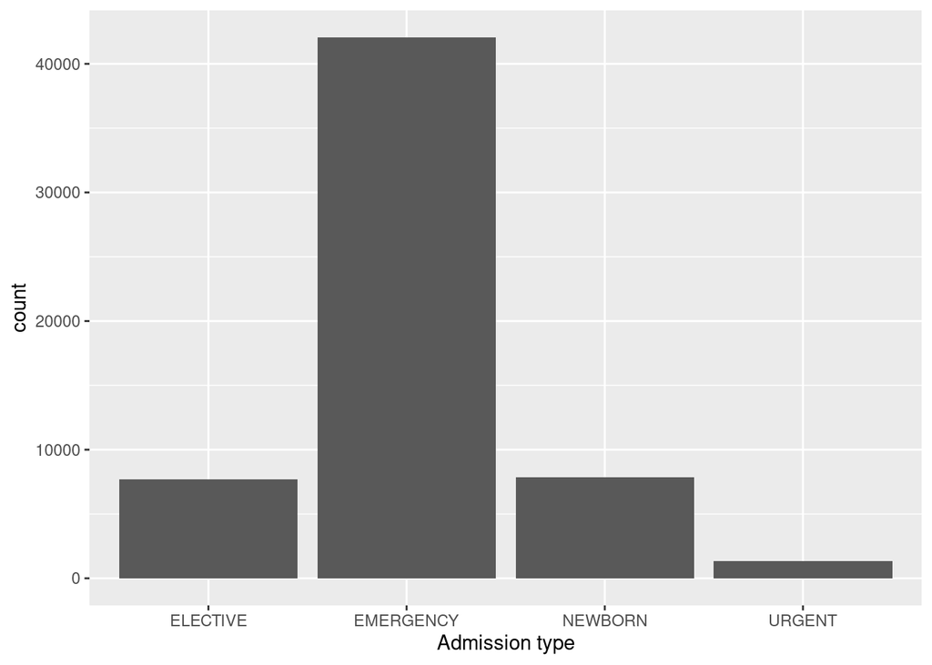

```r
admission %>%
  ggplot() +
  geom_bar(mapping = aes(x = ADMISSION_TYPE)) +
  labs(x = "Admission type")
```

Most admissions are emergency.

- Number of admissions per patient

```r
row <- select(admission, ROW_ID)
patient_ID <- select(admission, SUBJECT_ID)
nrow(row)/n_distinct(patient_ID)
```

```
## [1] 1.267756
```

So number of admissions per patient is about 1.27.

- Admission location

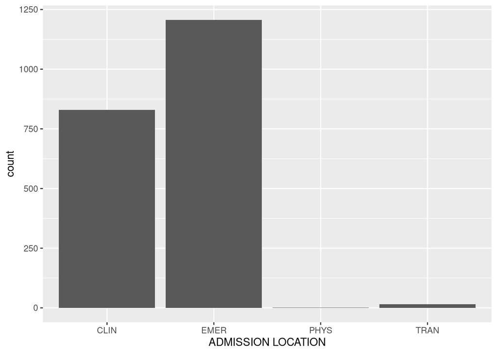

```r
na.omit(admission, 1:17) %>%
  ggplot() +
  geom_bar(mapping = aes(x = substr(ADMISSION_LOCATION, 1, 4))) +
  labs(x = "ADMISSION LOCATION")
```

It shows that EMERGENCY ROOM ADMIT and CLINIC REFERRAL/PREMATURE are the marjority of admission locations, among which EMERGENCY ROOM ADMIT is the busiest.

- Insurance

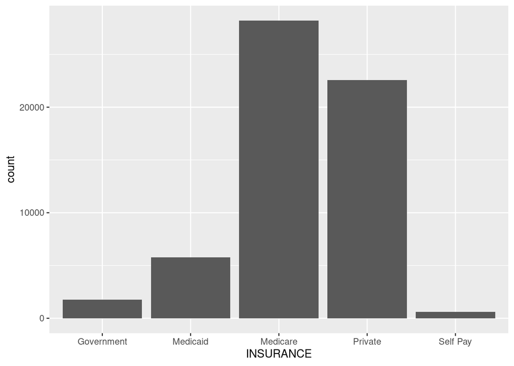

```r
admission %>%
  ggplot() +
  geom_bar(mapping = aes(INSURANCE)) +
  labs(x = "INSURANCE")
```

It shows that most patients have medicare and few patients are self-pay.

- Language

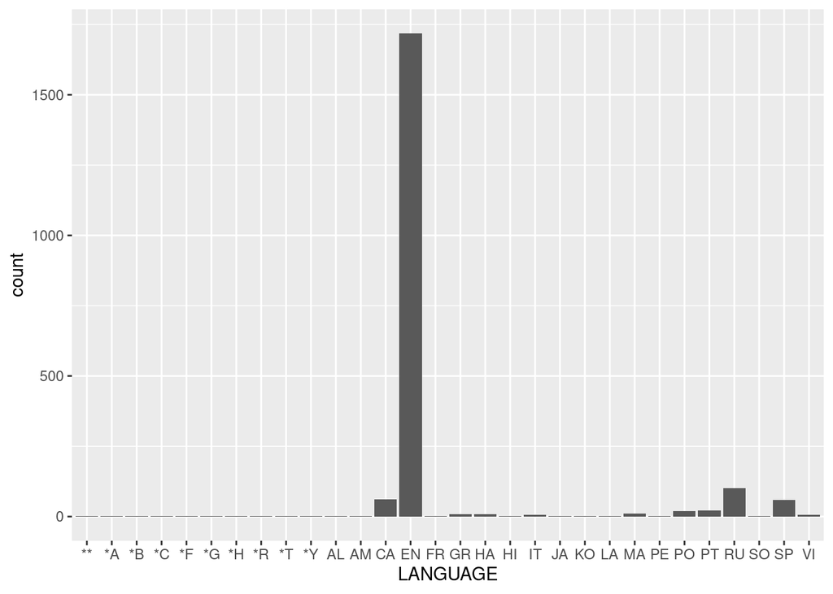

```r
na.omit(admission, 1:17) %>%
  ggplot() +
  geom_bar(mapping = aes(x = substr(LANGUAGE, 1, 2))) +
  labs(x = "LANGUAGE")
```

It is abvious that most patients are English-speaking.

- Religion

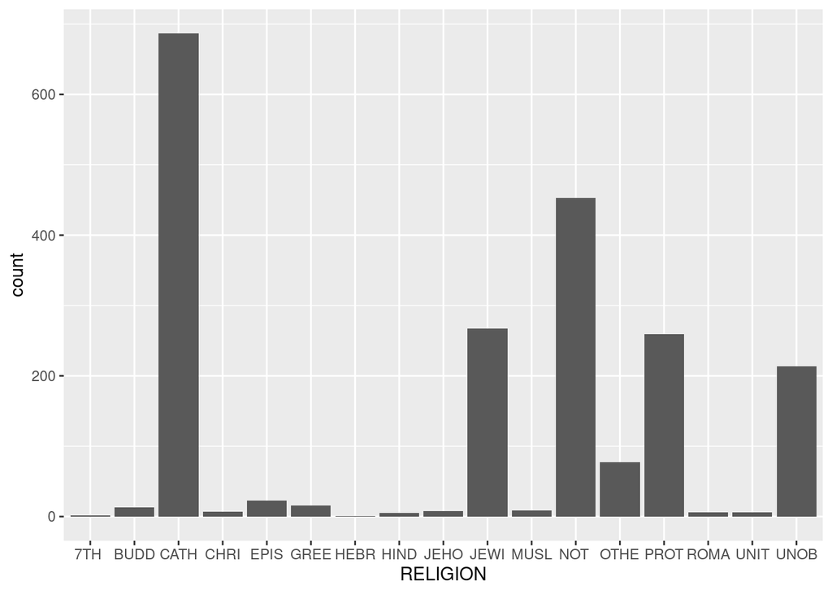

```r
na.omit(admission, 1:17) %>%
  ggplot() +
  geom_bar(mapping = aes(x = substr(RELIGION, 1, 4))) +
  labs(x = "RELIGION")
```

So most patients are CATHOLIC.

- Martial status

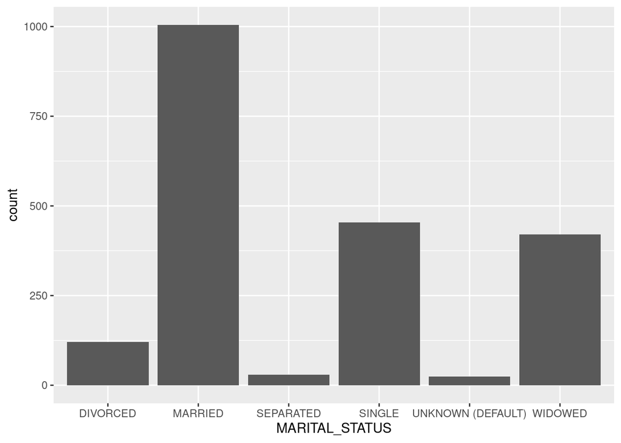

```r
na.omit(admission, 1:17) %>%
  ggplot() +
  geom_bar(mapping = aes(x = MARITAL_STATUS)) +
  labs(x = "MARITAL_STATUS")
```

So most patients are married.

- Ethnicity

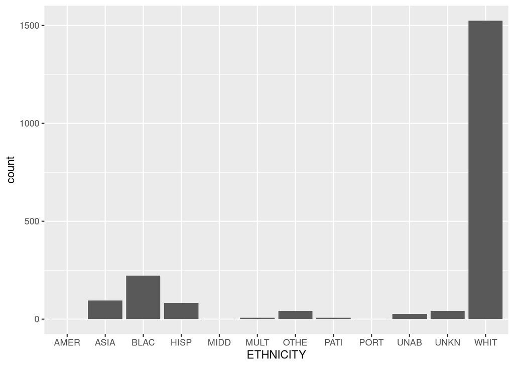

```r
na.omit(admission, 1:17) %>%
  ggplot() +
  geom_bar(mapping = aes(x = substr(ETHNICITY, 1, 4))) +
  labs(x = "ETHNICITY")
```

So most patients are white.

- Death

```r
DEATH <- select(admission, DEATHTIME)
death_rate <- sum(!is.na(DEATH))/nrow(DEATH)
death_rate
```

```
## [1] 0.09926072
```

So the death rate is about 10%.

## Q2

Link the data in `ADMISSION.csv` and `PATIENTS.csv` (https://mimic.physionet.org/mimictables/patients/) and summarize following variables using appropriate graphs:

- gender
- age at admission

**SOLUTION**

```r
patient <- read_csv("/home/203bdata/mimic-iii/PATIENTS.csv",
                    col_types = cols(ROW_ID = col_integer(),
                                     SUBJECT_ID = col_integer(),
                                     DOB = col_datetime()))
patient
```

```
## # A tibble: 46,520 x 8
##    ROW_ID SUBJECT_ID GENDER DOB                 DOD
##     <int>      <int> <chr>  <dttm>              <dttm>
##  1    234        249 F      2075-03-13 00:00:00 NA
##  2    235        250 F      2164-12-27 00:00:00 2188-11-22 00:00:00
##  3    236        251 M      2090-03-15 00:00:00 NA
##  4    237        252 M      2078-03-06 00:00:00 NA
##  5    238        253 F      2089-11-26 00:00:00 NA
##  6    239        255 M      2109-08-05 00:00:00 NA
##  7    240        256 M      2086-07-31 00:00:00 NA
##  8    241        257 F      2031-04-03 00:00:00 2121-07-08 00:00:00
##  9    242        258 F      2124-09-19 00:00:00 NA
## 10    243        260 F      2105-03-23 00:00:00 NA
## # … with 46,510 more rows, and 3 more variables: DOD_HOSP <dttm>,
## #   DOD_SSN <dttm>, EXPIRE_FLAG <dbl>
```

- Gender

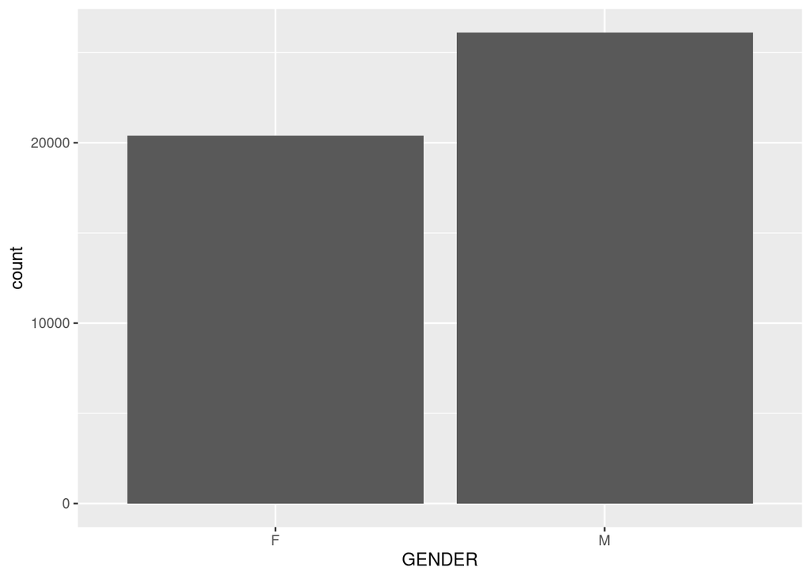

```r
patient %>%
  ggplot() +
  geom_bar(mapping = aes(x = GENDER)) +
  labs(x = "GENDER")
```

We can see that more patients are male.

- Age at Admission

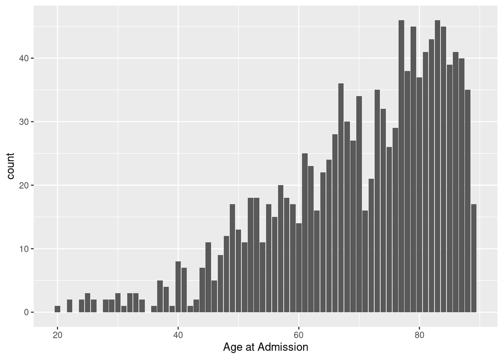

```r
allinf <- inner_join(na.omit(patient, 4:4), na.omit(admission, 5:5), by = "SUBJECT_ID")
allinf %>%
  mutate(age = year(ADMITTIME) - year(DOB)) %>%
  filter(0 <= age & age < 150) %>%
  ggplot(aes(x = age)) +
  geom_bar() +
  labs(x = "Age at Admission")
```

A better picture of age at admission is shown below:

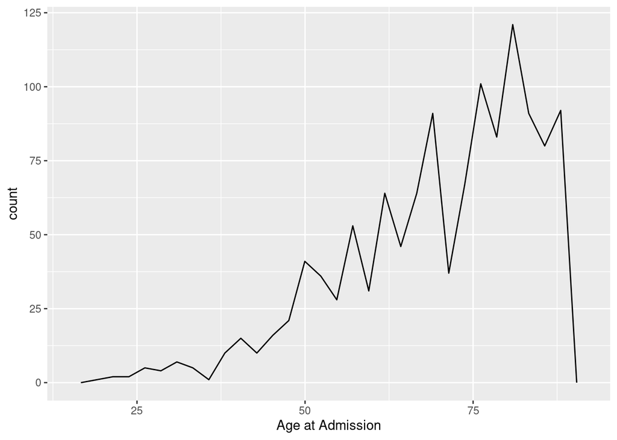

```r
allinf <- inner_join(na.omit(patient, 4:4), na.omit(admission, 5:5), by = "SUBJECT_ID")
allinf %>%
  mutate(age = year(ADMITTIME) - year(DOB)) %>%
  filter(0 <= age & age < 150) %>%
  ggplot(aes(x = age)) +
  geom_freqpoly() +
  labs(x = "Age at Admission")
```

It shows that the majority of patients are senior (over 60 years old).

## Q3

`ICUSTAYS.csv` (https://mimic.physionet.org/mimictables/icustays/) contains data about Intensive Care Units (ICU) stays. Summarize following variables using appropriate graphs:

- length of ICU stay
- first ICU unit
- gender
- age

**SOLUTION**

```r
ICUSTAYS <- read_csv("/home/203bdata/mimic-iii/ICUSTAYS.csv",
                    col_types = cols(ROW_ID = col_integer(),
                                     SUBJECT_ID = col_integer(),
                                     HADM_ID = col_integer(),
                                     ICUSTAY_ID = col_integer(),
                                     FIRST_WARDID = col_integer(),
                                     LAST_WARDID = col_integer(),
                                     INTIME = col_datetime(),
                                     OUTTIME = col_datetime()))
ICUSTAYS
```

```
## # A tibble: 61,532 x 12
##    ROW_ID SUBJECT_ID HADM_ID ICUSTAY_ID DBSOURCE FIRST_CAREUNIT LAST_CAREUNIT
##     <int>      <int>   <int>      <int> <chr>    <chr>          <chr>
##  1    365        268  110404     280836 carevue  MICU           MICU
##  2    366        269  106296     206613 carevue  MICU           MICU
##  3    367        270  188028     220345 carevue  CCU            CCU
##  4    368        271  173727     249196 carevue  MICU           SICU
##  5    369        272  164716     210407 carevue  CCU            CCU
##  6    370        273  158689     241507 carevue  MICU           MICU
##  7    371        274  130546     254851 carevue  MICU           MICU
##  8    372        275  129886     219649 carevue  CCU            CCU
##  9    373        276  135156     206327 carevue  CCU            CCU
## 10    374        277  171601     272866 carevue  NICU           NICU
## # … with 61,522 more rows, and 5 more variables: FIRST_WARDID <int>,
## #   LAST_WARDID <int>, INTIME <dttm>, OUTTIME <dttm>, LOS <dbl>
```

- Length of ICU Stay

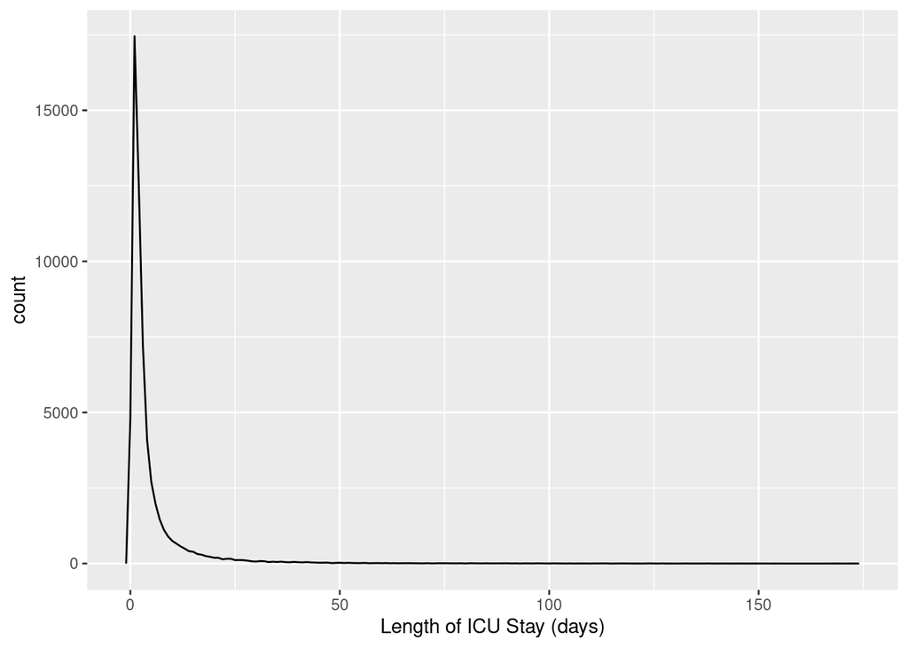

```r
ICUSTAYS %>%
  mutate(ICU_stay = as.numeric(as.duration(OUTTIME - INTIME)/86400)) %>%
  ggplot(aes(x = ICU_stay)) +
  geom_freqpoly(binwidth = 1) +
  labs(x = "Length of ICU Stay (days)")
```

A better picture of the pattern of length of ICU stay is shown below.

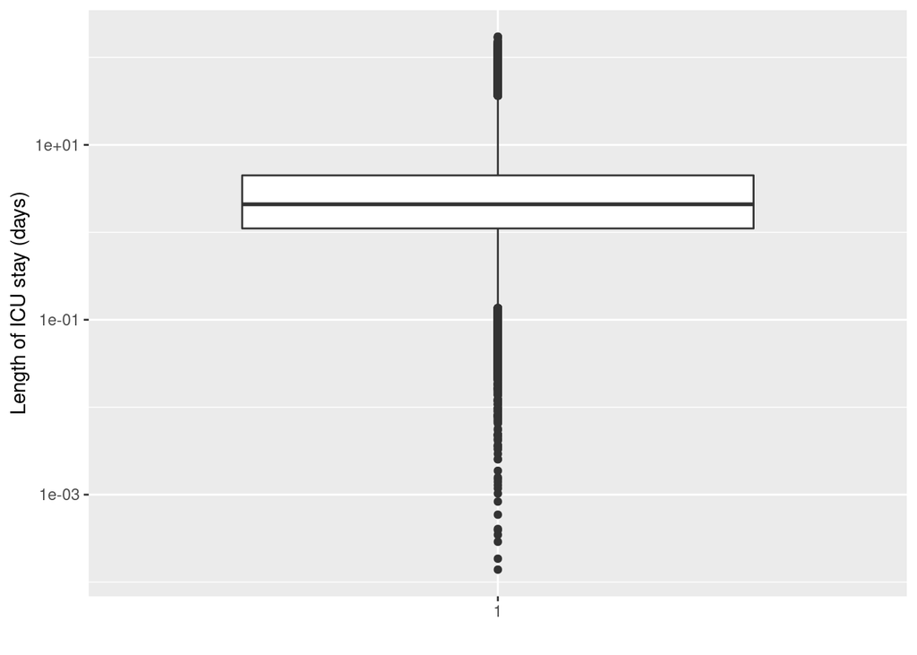

```r
ICUSTAYS %>%
  mutate(ICU_stay = as.numeric(as.duration(OUTTIME - INTIME)/86400)) %>%
  ggplot() +
  geom_boxplot(mapping = aes(x = factor(1), y = ICU_stay)) +
  labs(x = "", y = "Length of ICU stay (days)") +
  scale_y_log10()
```

We can see that ICU stay is mainly about 1 day to 4 day.

- First ICU unit

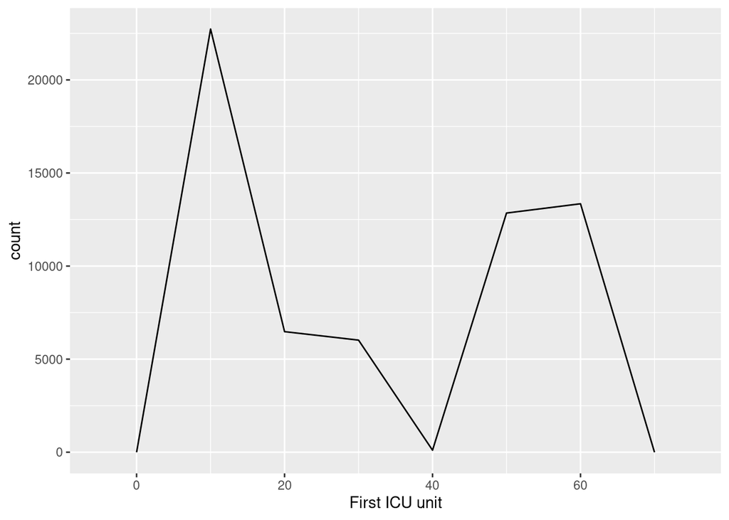

```r
ICUSTAYS %>%
  ggplot(aes(x = FIRST_WARDID)) +
  geom_freqpoly(binwidth = 10) +
  labs(x = "First ICU unit")
```

- Gender

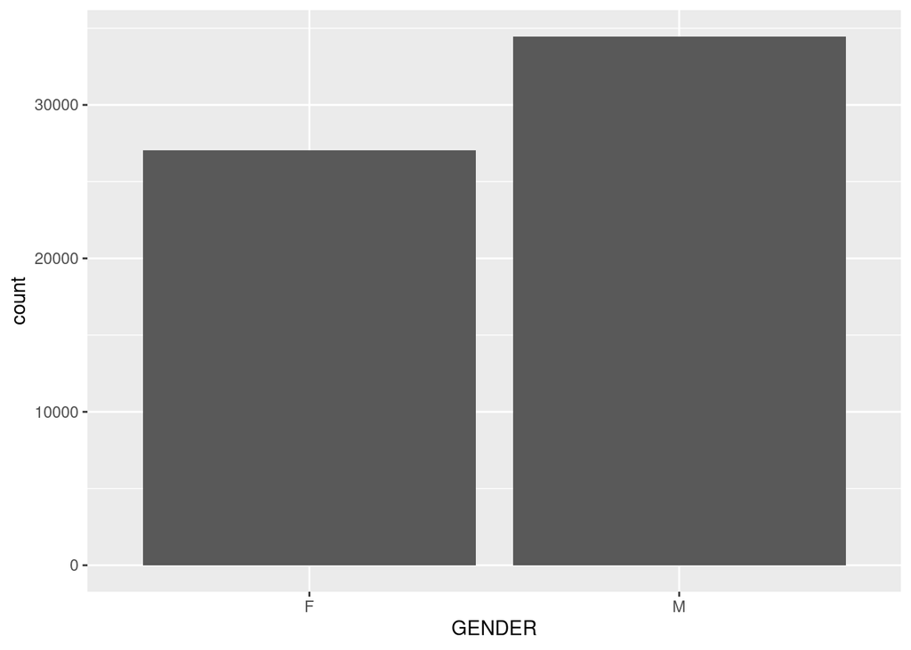

```r
allinf2 <- inner_join(ICUSTAYS, patient, by = "SUBJECT_ID")
allinf2 %>%
  ggplot() +
  geom_bar(mapping = aes(x = GENDER)) +
  labs(x = "GENDER")
```

We can see that more patients are male.

- Age

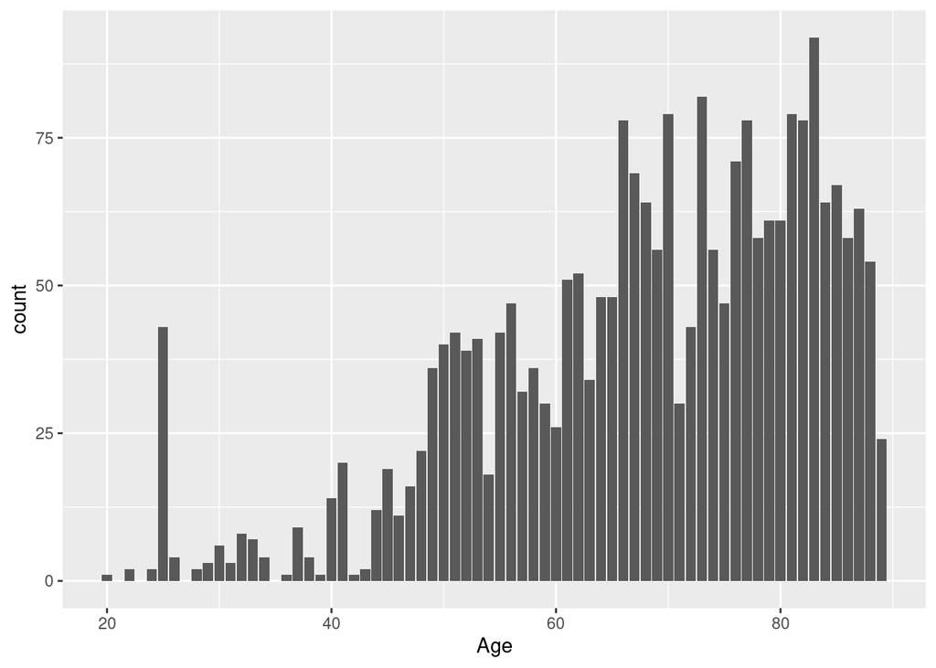

```r
allinf %>%
  mutate(age = year(ADMITTIME) - year(DOB)) %>%
  filter(0 <= age & age < 150)  %>%
  inner_join(ICUSTAYS, by = "SUBJECT_ID") %>%
  ggplot() +
  geom_bar(mapping = aes(x = age)) +
  labs(x = "Age")
```

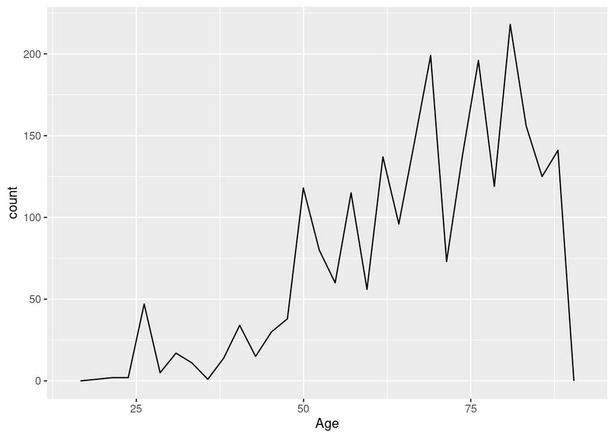

```r
allinf %>%
  mutate(age = year(ADMITTIME) - year(DOB)) %>%
  filter(0 <= age & age < 150)  %>%
  inner_join(ICUSTAYS, by = "SUBJECT_ID") %>%
  ggplot() +
  geom_freqpoly(mapping = aes(x = age)) +
  labs(x = "Age")
```

It shows that most ICU patients are senior.

## Q4

`CHARTEVENTS.csv` (https://mimic.physionet.org/mimictables/chartevents/) contains all the charted data available for a patient. During their ICU stay, the primary repository of a patient’s information is their electronic chart. The `ITEMID` variable indicates a single measurement type in the database. The `VALUE` variable is the value measured for `ITEMID`.

`D_ITEMS.csv` (https://mimic.physionet.org/mimictables/d_items/) is the dictionary for the `ITEMID` in `CHARTEVENTS.csv`. Find potential values of `ITEMID` that correspond to systolic blood pressure, i.e., `LABEL` contains the string `systolic`.

Compile a tibble that contains the first ICU stay of unique patients, with the patient’s demographic information, the first systolic blood pressure measurement during ICU stay, and whether the patient died within 30 days of hospitcal admission.

**SOLUTION**

```r
chartevents <- read_csv("/home/203bdata/mimic-iii/CHARTEVENTS.csv",
                        col_types = cols(ITEMID = col_integer(),
                                         ROW_ID = col_integer(),
                                         SUBJECT_ID = col_integer(),
                                         HADM_ID = col_integer(),
                                         ICUSTAY_ID = col_integer(),
                                         CGID = col_integer(),
                                         VALUE = col_number()))
chartevents
```

```
## # A tibble: 1,048,575 x 15
##    ROW_ID SUBJECT_ID HADM_ID ICUSTAY_ID ITEMID CHARTTIME STORETIME  CGID  VALUE
##     <int>      <int>   <int>      <int>  <int> <chr>     <chr>     <int>  <dbl>
##  1    788         36  165660     241249 223834 5/12/34 … 5/12/34 … 17525  15
##  2    789         36  165660     241249 223835 5/12/34 … 5/12/34 … 17525 100
##  3    790         36  165660     241249 224328 5/12/34 … 5/12/34 … 20823   0.37
##  4    791         36  165660     241249 224329 5/12/34 … 5/12/34 … 20823   6
##  5    792         36  165660     241249 224330 5/12/34 … 5/12/34 … 20823   2.5
##  6    793         36  165660     241249 224331 5/12/34 … 5/12/34 … 20823   0
##  7    794         36  165660     241249 224332 5/12/34 … 5/12/34 … 17525   3
##  8    795         36  165660     241249 224663 5/12/34 … 5/12/34 … 17525   8
##  9    796         36  165660     241249 224665 5/12/34 … 5/12/34 … 17525   1.11
## 10    797         36  165660     241249 220224 5/12/34 … 5/12/34 … 20889  58
## # … with 1,048,565 more rows, and 6 more variables: VALUENUM <dbl>,
## #   VALUEUOM <chr>, WARNING <dbl>, ERROR <dbl>, RESULTSTATUS <lgl>,
## #   STOPPED <lgl>
```

```r
D_items <- read_csv("/home/203bdata/mimic-iii/D_ITEMS.csv",
                    col_types = cols(ROW_ID = col_integer(),
                                     ITEMID = col_integer(),
                                     LABEL = col_character(),
                                     ABBREVIATION = col_character(),
                                     DBSOURCE = col_character(),
                                     LINKSTO = col_character(),
                                     CATEGORY = col_character(),
                                     UNITNAME = col_character(),
                                     PARAM_TYPE = col_character(),
                                     CONCEPTID = col_integer()))
D_items <- select(D_items, ITEMID, LABEL, ABBREVIATION, CATEGORY, UNITNAME)
filter(D_items, grepl("systolic", LABEL))
```

```
## # A tibble: 5 x 5
##   ITEMID LABEL                    ABBREVIATION           CATEGORY       UNITNAME
##    <int> <chr>                    <chr>                  <chr>          <chr>
## 1 226850 RV systolic pressure(PA… RV systolic pressure(… PA Line Inser… mmHg
## 2 226852 PA systolic pressure(PA… PA systolic pressure(… PA Line Inser… mmHg
## 3 220050 Arterial Blood Pressure… ABPs                   Routine Vital… mmHg
## 4 220059 Pulmonary Artery Pressu… PAPs                   Hemodynamics   mmHg
## 5 220179 Non Invasive Blood Pres… NBPs                   Routine Vital… mmHg
```

Potential values of ITEMID that correspond to systolic blood pressure include 226850, 226852, 220050, 220059, and 220179.

```r
# demographic information
# whether the patient died within 30 days of hospitcal admission
demographic_information <- select(admission, ADMITTIME, DEATHTIME, SUBJECT_ID:ETHNICITY) %>%
  mutate("death_time" = as.numeric(as.duration(DEATHTIME - ADMITTIME) / 86400))  %>%
  mutate("if_30_death" = FALSE)
demographic_information[, 15][demographic_information[, 14] > 30] <- TRUE
# the first systolic blood pressure measurement during ICU stay
first_ICU <- select(ICUSTAYS, SUBJECT_ID, starts_with("FIRST"), INTIME)
final_data <- inner_join(first_ICU, demographic_information, by = "SUBJECT_ID")
chartevents <- distinct(chartevents, SUBJECT_ID, .keep_all = TRUE)
final_data <- left_join(final_data, chartevents, by = "SUBJECT_ID")
final_data <- select(final_data, SUBJECT_ID:INTIME, ADMISSION_TYPE:ETHNICITY, if_30_death, CHARTTIME:VALUEUOM)
final_data
```

```
## # A tibble: 116,426 x 19
##    SUBJECT_ID FIRST_CAREUNIT FIRST_WARDID INTIME              ADMISSION_TYPE
##         <int> <chr>                 <int> <dttm>              <chr>
##  1        268 MICU                     52 2198-02-14 23:27:38 EMERGENCY
##  2        269 MICU                     52 2170-11-05 11:05:29 EMERGENCY
##  3        270 CCU                      57 2128-06-24 15:05:20 ELECTIVE
##  4        271 MICU                     52 2120-08-07 23:12:42 EMERGENCY
##  5        272 CCU                      57 2186-12-25 21:08:04 EMERGENCY
##  6        273 MICU                     52 2141-04-19 06:12:05 EMERGENCY
##  7        274 MICU                     12 2114-06-28 22:28:44 EMERGENCY
##  8        275 CCU                       7 2170-10-07 11:28:53 EMERGENCY
##  9        276 CCU                      57 2147-11-20 09:02:23 EMERGENCY
## 10        277 NICU                     56 2132-10-21 21:11:46 NEWBORN
## # … with 116,416 more rows, and 14 more variables: ADMISSION_LOCATION <chr>,
## #   DISCHARGE_LOCATION <chr>, INSURANCE <chr>, LANGUAGE <chr>, RELIGION <chr>,
## #   MARITAL_STATUS <chr>, ETHNICITY <chr>, if_30_death <lgl>, CHARTTIME <chr>,
## #   STORETIME <chr>, CGID <int>, VALUE <dbl>, VALUENUM <dbl>, VALUEUOM <chr>
```